# NCAA 2025 Women’s Track: One-ANOVA | SOLUTIONS

```r
library(readr)
library(ggplot2)
library(dplyr)
womenTrack <- read_csv("WomensTrack2025.csv")
```

1. Filter the dataset to only include events considered part of the sprint discipline. These would be the 100, 200, and 400 meter events.

```r
womenTrack <- womenTrack |> filter(Event %in% c(100, 200, 400))
```

2. Create a boxplot with `Event` (as a factor) on the x-axis and `Speed` on the y-axis. Group by Event to get a box for each event. Describe what you see.

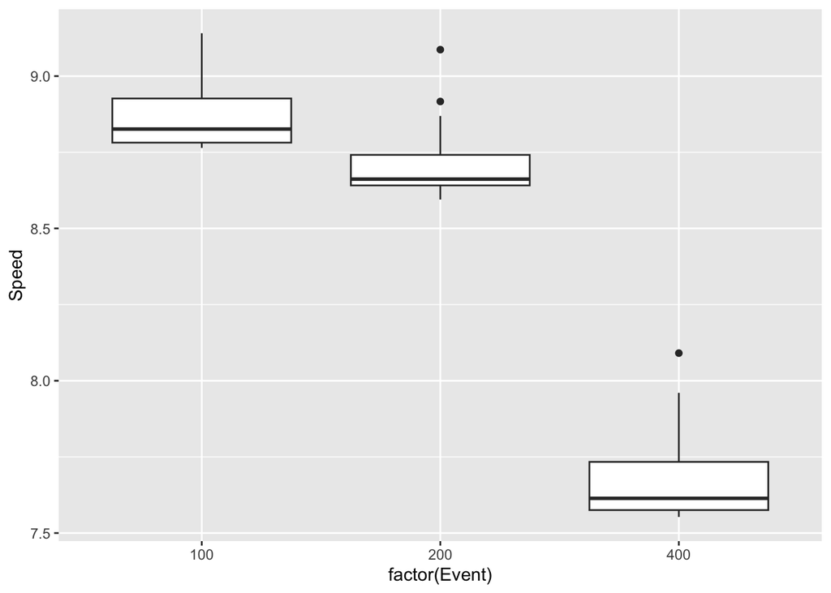

```r
ggplot(data = womenTrack,
       aes(x = factor(Event),
           y = Speed,
           group = Event)
       ) +
  geom_boxplot()
```

All the events seem to have different means. The 100 and 200 m events have a small amount of overlap, but, for the most part, the boxes are very distinct.

We would like to determine if the speed means are significantly statistically different between events.

3. Explain why **One-Way ANOVA** may be a good candidate method to use here.

A One-Way ANOVA test is useful in this scenario because the independent variable in the relationship is a factor with 3 possible levels.

4. Before using ANOVA, we will first need to check for assumptions.

The 3 assumptions are:

- **Independence:** if the samples are collected independently from each other
- **Normality:** if the data is normally distributed (or we have sufficiently large sample sizes such that the Central Limit Theorem holds)
- **Constant Variance:** if the difference between observed and predicted values is equal among data points.

Evaluate the three assumptions. Use your boxplots to assist. You may also want to investigate the data directly (paying close attention to the names of the runners).

**Solution:** - Constant Variance: The 100 and 400 m boxplots have approximately the same variation. The 200 m box has a slightly lower variation. We can check the standard deviations for each group using the code below. (Note the the ratio of largest to smallest is $0.128/0.0942 \approx 1.36$).

```r
womenTrack |>
  group_by(Event) |>
  summarize(n = n(), sd = sd(Speed))
```

```
# A tibble: 3 × 3
  Event     n     sd
  <dbl> <int>  <dbl>
1   100    50 0.100
2   200    51 0.0942
3   400    50 0.128
```

- Normality: All 3 events have some skew. The 200 and 400 m events have outliers, but with the amount of observations, these outliers are most likely not too highly influential.
- Independence: This condition fails for two reasons. First, Division 1 track runners do not represent a random sample of runners (one could argue they are a representative of successful/competitive runners). Secondly, several runners appear in multiple events, even all three.

*This could lead to a nice discussion with students on the trade off between weak assumptions and value gained from the analysis.*

5. Regardless of your evaluation of the assumptions, we will perform the ANOVA hypothesis test - recognizing that it may not be perfect, but it is still potentially informative.
1. State the null hypothesis and alternative hypotheses in words.

*Null - There is no difference in the mean speed between sprint events*

*Alternative - Not all sprint events have equal mean speeds*

2. Perform an ANOVA hypothesis test to determine if there are any statistically significant differences in `Speed` between the events using the aov() function. You will need to change `Event` to a factor.

```r
anova_result <- aov(Speed ~ as.factor(Event), data = womenTrack)
summary(anova_result)
```

```
                  Df Sum Sq Mean Sq F value Pr(>F)
as.factor(Event)   2  41.80  20.902    1774 <2e-16 ***
Residuals        148   1.74   0.012
---
Signif. codes:  0 '***' 0.001 '**' 0.01 '*' 0.05 '.' 0.1 ' ' 1
```

3. Report the F-Statistic, degrees of freedom, and p-value.

4. Use the p-value to make a conclusion.

*There is clear statistical evidence to conclude that there is a least one pair of events with different mean speeds (F-Statistic = 1774, P-value = approximately 0, df = 2 and 148).*

6. In order to find out which events are statistically discernible from each other we can perform a Post Hoc Tukey Test.

Perform a Post Hoc Tukey test using the `TukeyHSD()` function to determine between which events there is a statistically significant difference in speed Report the results.

```r
tukey_result <- TukeyHSD(anova_result)
tukey_result
```

```
  Tukey multiple comparisons of means
    95% family-wise confidence level

Fit: aov(formula = Speed ~ as.factor(Event), data = womenTrack)

$`as.factor(Event)`
              diff        lwr        upr p adj
200-100 -0.1661343 -0.2172789 -0.1149897     0
400-100 -1.1925509 -1.2439481 -1.1411537     0
400-200 -1.0264166 -1.0775612 -0.9752719     0
```

All of the events have statistically significant differences in speed.

7. The Tukey Test also provides a confidence interval.

Interpret the confidence interval for the 100 and 200 meter comparison in the context of this data situation.

*With 95% confidence, runners in the 100 meter event ran between, on average, 0.11 and 0.22 m/s faster than runners in the 200 meter event.*

8. The strategy of track running changes based on the distance of the event being run. For shorter events, athletes have to go all out and expend a lot of energy to maintain their fastest possible pace for a short time. As the event distance increase, maintaining the highest possible speed becomes less realistic, requiring runners to have a different approach.

Do the results from Tukey’s HSD support this trend?

*Yes the tukey test does support this trend showing the significant difference between the events based on the distance. Specifically, when the event had a longer distance, runners had lower speeds*